# Clima do Brasil — Supervisionado vs Não-Supervisionado

## 5.4 Distância Intra-Cluster — Os Clusters Estão Ficando Mais Difusos?

Calculamos o WSS (Within-cluster Sum of Squares) por período para verificar se a separação entre clusters está se alterando.

**Ver código**

Métricas de qualidade dos clusters por período

| period | wss | sil_mean |
| --- | --- | --- |
| 1980–1994 | 16.175 | 0.390 |
| 1995–2009 | 18.032 | 0.424 |
| 2010–2024 | 16.312 | 0.513 |

Figure 27: WSS (compactação dos clusters) e Silhouette médio por período. WSS crescente = clusters menos compactos. Silhouette decrescente = pior separação.

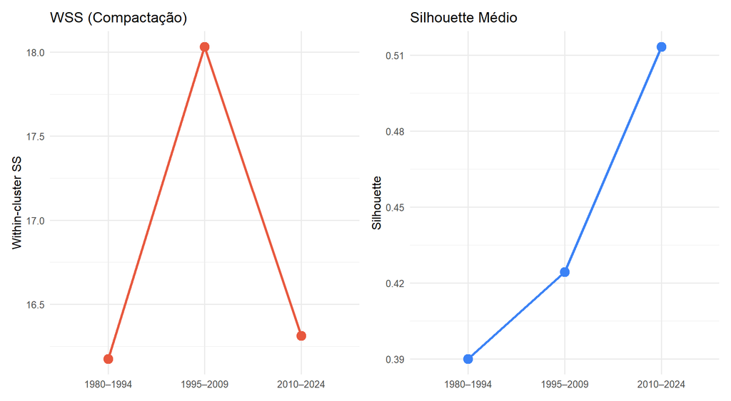

```r
compute_cluster_quality <- function(df, period_label) {
  prof <- df |>
    filter(period == period_label) |>
    select(city, temp_mean, temp_range, precip, radiation, wind) |>
    column_to_rownames("city")

  X_s <- scale(prof)
  k <- min(3, nrow(X_s) - 1)
  set.seed(42)
  km <- kmeans(X_s, centers = k, nstart = 25)

  sil <- silhouette(km$cluster, dist(X_s))
  tibble(
    period   = period_label,
    wss      = km$tot.withinss,
    sil_mean = mean(sil[, "sil_width"])
  )
}

quality_temporal <- map(periods, ~compute_cluster_quality(profiles_temporal, .x)) |>
  list_rbind()

p_wss <- ggplot(quality_temporal, aes(period, wss, group = 1)) +
  geom_line(linewidth = 1.2, color = "#E8583E") +
  geom_point(size = 4, color = "#E8583E") +
  labs(title = "WSS (Compactação)", x = NULL, y = "Within-cluster SS") +
  theme_minimal(base_size = 12)

p_sil <- ggplot(quality_temporal, aes(period, sil_mean, group = 1)) +
  geom_line(linewidth = 1.2, color = "#3B82F6") +
  geom_point(size = 4, color = "#3B82F6") +
  labs(title = "Silhouette Médio", x = NULL, y = "Silhouette") +
  theme_minimal(base_size = 12)

p_wss + p_sil

quality_temporal |>
  mutate(across(where(is.numeric), ~round(., 3))) |>
  knitr::kable(caption = "Métricas de qualidade dos clusters por período")
```

**Note**

**Interpretação da dinâmica dos clusters:** se o WSS aumenta e o Silhouette diminui ao longo dos períodos, os perfis climáticos estão se tornando mais homogêneos entre regiões — o que poderia indicar convergência climática (possivelmente ligada ao aquecimento global). Se uma cidade específica muda de cluster, isso sugere que seu microclima está se deslocando em relação aos vizinhos geográficos. A trajetória no espaço Temperatura × Precipitação mostra a direção e magnitude dessas mudanças.